# Summary of operating model index fits

ABT-MSE

Tom Carruthers

May 24, 2021

# 1 Introduction / notes

Index fitting report for reference grid OMs with length composition weighting of 1 (factor level H)

```
## R Version:  R version 4.0.4 (2021-02-15)
```

# 2 Residuals in indices

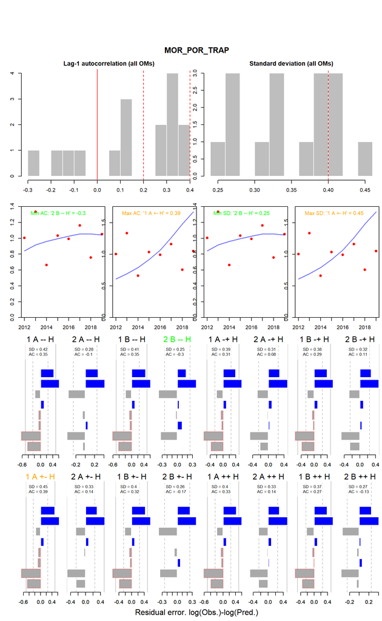

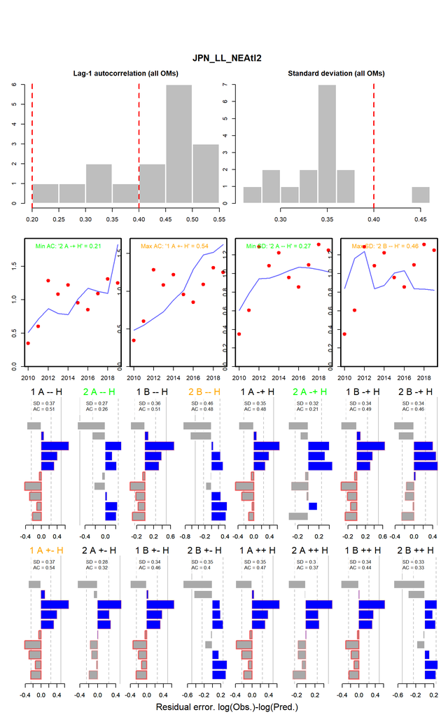

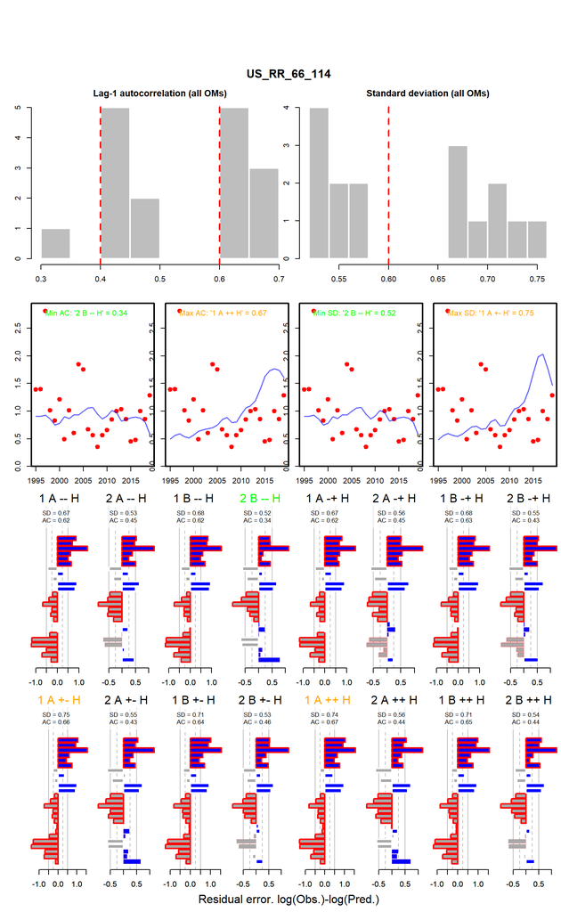

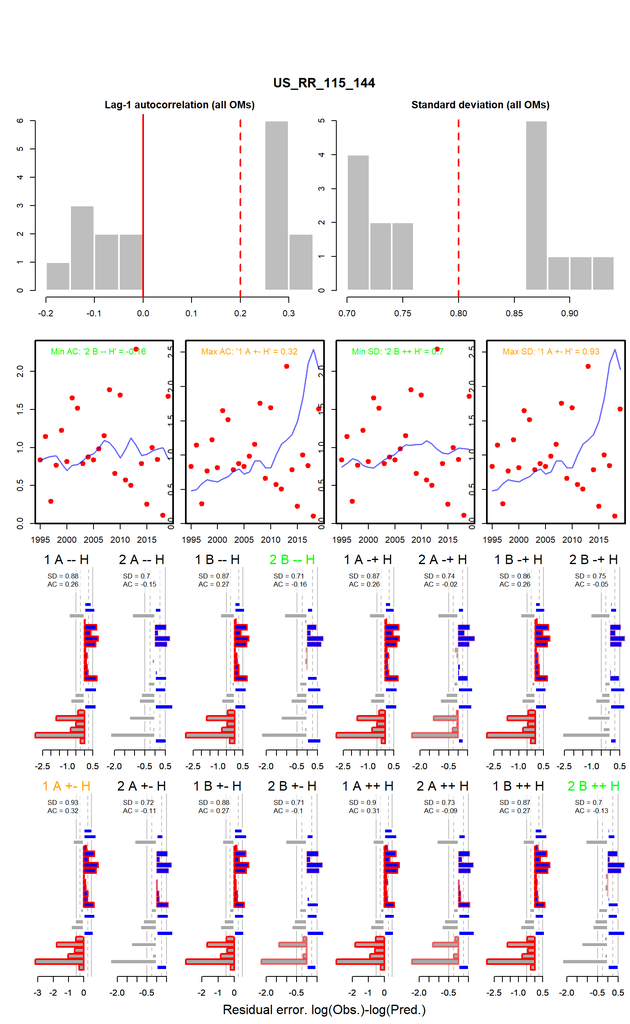

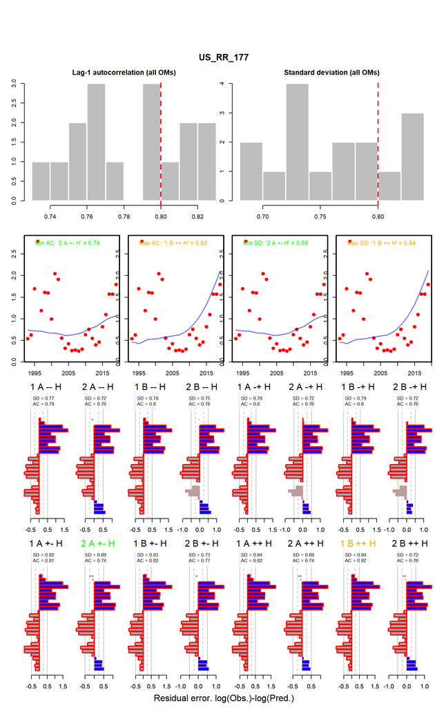

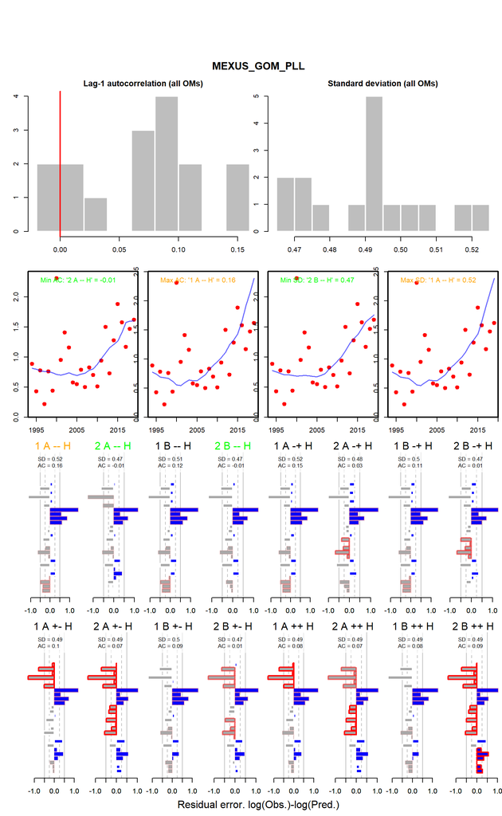

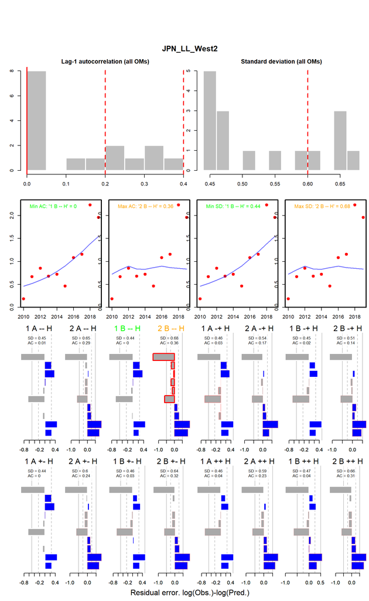

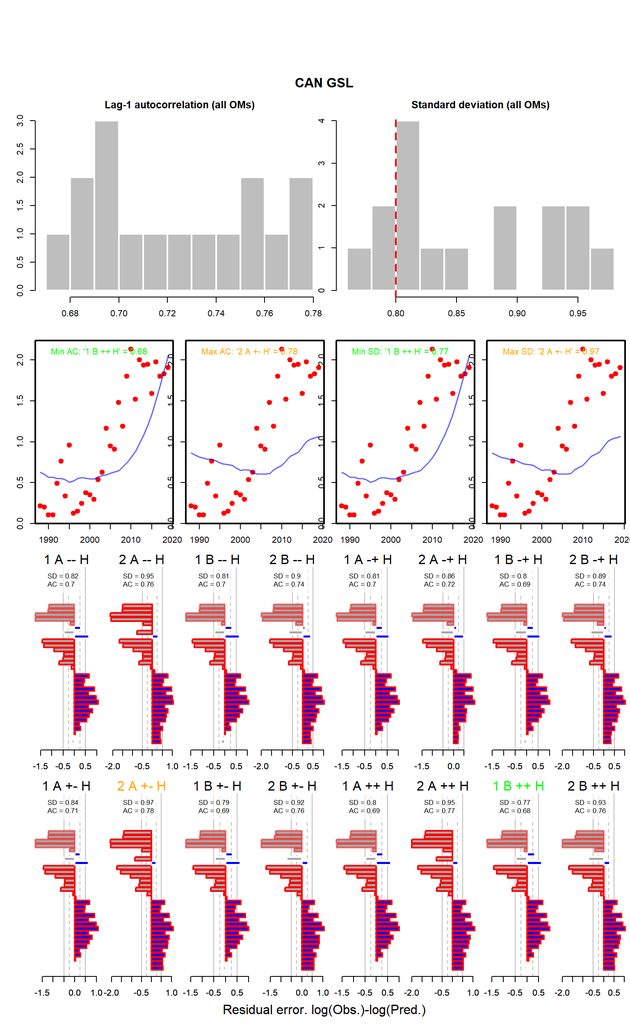

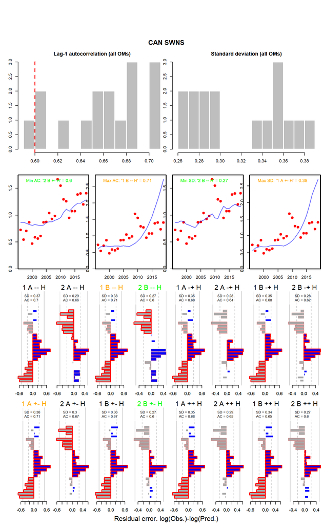

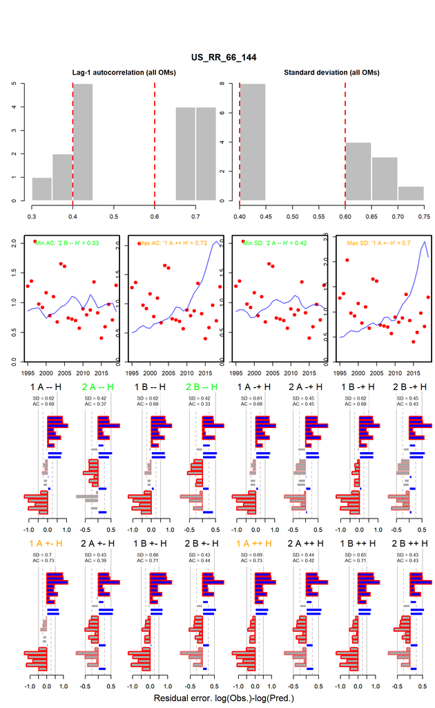

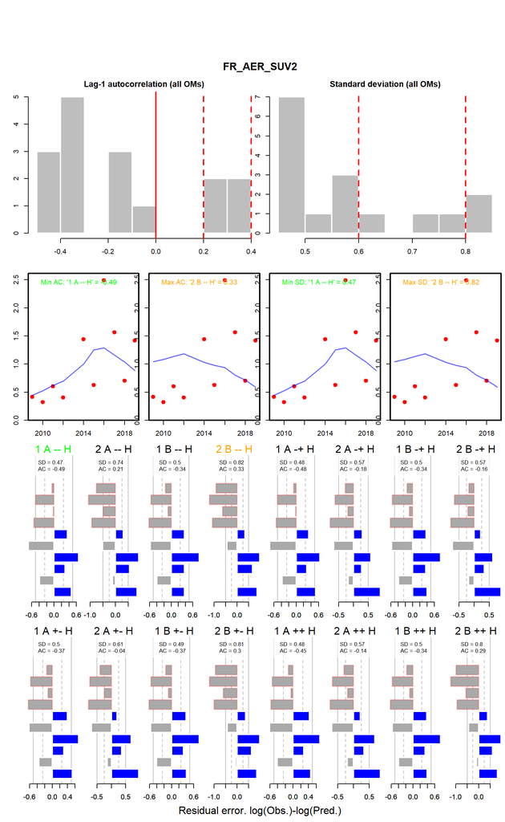

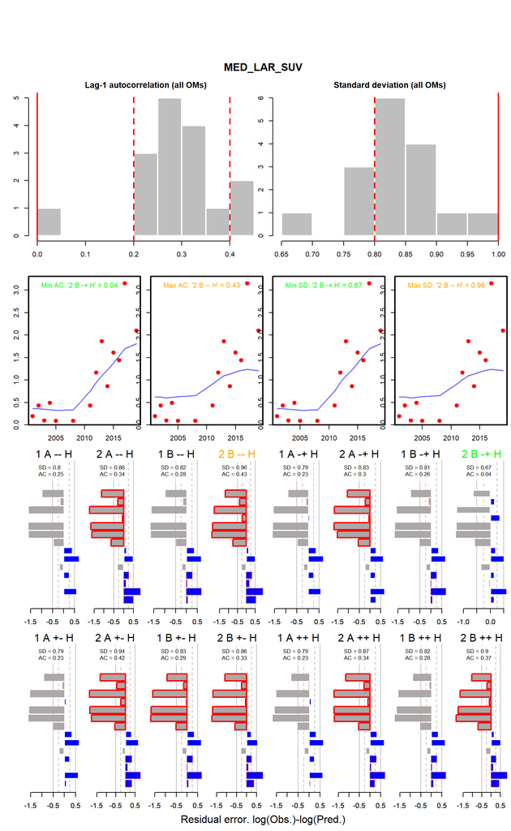

[2 more figures not shown]

# 3 Standard Deviation of Residuals

Table 1. Standard deviation in log residuals

| OM | R | P | S | L | MOR POR TRAP | JPN LL NEAtl2 | US RR 66 114 | US RR 115 144 | US RR 177 | MEXUS GOM PLL | JPN LL West2 | CAN GSL | CAN SWNS | US RR 66 144 | FR AER SUV2 | MED LAR SUV | GOM LAR SUV | GBYP AER SUV BAR |
| --- | --- | --- | --- | --- | --- | --- | --- | --- | --- | --- | --- | --- | --- | --- | --- | --- | --- | --- |
| 25 | 1 | A | -- | H | 0.42 | 0.37 | 0.67 | 0.88 | 0.77 | 0.52 | 0.45 | 0.82 | 0.37 | 0.62 | 0.47 | 0.8 | 0.54 | 0.6 |
| 26 | 2 | A | -- | H | 0.28 | 0.27 | 0.53 | 0.7 | 0.72 | 0.47 | 0.65 | 0.95 | 0.29 | 0.42 | 0.74 | 0.86 | 0.59 | 0.8 |
| 28 | 1 | B | -- | H | 0.41 | 0.36 | 0.68 | 0.87 | 0.78 | 0.51 | 0.44 | 0.81 | 0.38 | 0.62 | 0.5 | 0.82 | 0.54 | 0.63 |
| 29 | 2 | B | -- | H | 0.25 | 0.46 | 0.52 | 0.71 | 0.75 | 0.47 | 0.68 | 0.9 | 0.27 | 0.42 | 0.82 | 0.96 | 0.56 | 0.85 |
| 31 | 1 | A | -+ | H | 0.39 | 0.35 | 0.67 | 0.87 | 0.78 | 0.52 | 0.46 | 0.81 | 0.35 | 0.61 | 0.48 | 0.79 | 0.53 | 0.6 |
| 32 | 2 | A | -+ | H | 0.31 | 0.32 | 0.56 | 0.74 | 0.72 | 0.48 | 0.54 | 0.86 | 0.28 | 0.45 | 0.57 | 0.83 | 0.54 | 0.69 |
| 34 | 1 | B | -+ | H | 0.38 | 0.34 | 0.68 | 0.86 | 0.79 | 0.5 | 0.45 | 0.8 | 0.35 | 0.62 | 0.5 | 0.81 | 0.54 | 0.63 |
| 35 | 2 | B | -+ | H | 0.32 | 0.34 | 0.55 | 0.75 | 0.72 | 0.47 | 0.51 | 0.89 | 0.28 | 0.45 | 0.57 | 0.67 | 0.56 | 0.68 |
| 37 | 1 | A | +- | H | 0.45 | 0.37 | 0.75 | 0.93 | 0.82 | 0.49 | 0.44 | 0.84 | 0.38 | 0.7 | 0.5 | 0.79 | 0.59 | 0.63 |
| 38 | 2 | A | +- | H | 0.33 | 0.28 | 0.55 | 0.72 | 0.69 | 0.49 | 0.6 | 0.97 | 0.3 | 0.43 | 0.61 | 0.94 | 0.68 | 0.7 |

[output cut: 6 more lines]

| OM | R | P | S | L | MOR POR TRAP | JPN LL NEAtl2 | US RR 66 114 | US RR 115 144 | US RR 177 | MEXUS GOM PLL | JPN LL West2 | CAN GSL | CAN SWNS | US RR 66 144 | FR AER SUV2 | MED LAR SUV | GOM LAR SUV | GBYP AER SUV BAR | NA |
| --- | --- | --- | --- | --- | --- | --- | --- | --- | --- | --- | --- | --- | --- | --- | --- | --- | --- | --- | --- |
|  |  |  |  |  |  | 0.35 | 0.34 | 0.62 | 0.8 | 0.76 | 0.49 | 0.53 | 0.86 | 0.32 | 0.54 | 0.59 | 0.83 | 0.59 | 0.68 |

# 4 Standard Error of Residuals

Table 2. Standard error in log residuals (St.Dev/(n)^0.5)

| OM | R | P | S | L | MOR POR TRAP | JPN LL NEAtl2 | US RR 66 114 | US RR 115 144 | US RR 177 | MEXUS GOM PLL | JPN LL West2 | CAN GSL | CAN SWNS | US RR 66 144 | FR AER SUV2 | MED LAR SUV | GOM LAR SUV | GBYP AER SUV BAR |
| --- | --- | --- | --- | --- | --- | --- | --- | --- | --- | --- | --- | --- | --- | --- | --- | --- | --- | --- |
| 25 | 1 | A | -- | H | 0.15 | 0.12 | 0.13 | 0.18 | 0.15 | 0.1 | 0.14 | 0.14 | 0.08 | 0.12 | 0.15 | 0.21 | 0.08 | 0.25 |
| 26 | 2 | A | -- | H | 0.1 | 0.09 | 0.11 | 0.14 | 0.14 | 0.09 | 0.21 | 0.17 | 0.06 | 0.08 | 0.23 | 0.23 | 0.09 | 0.33 |
| 28 | 1 | B | -- | H | 0.15 | 0.11 | 0.14 | 0.17 | 0.15 | 0.1 | 0.14 | 0.14 | 0.08 | 0.12 | 0.16 | 0.22 | 0.08 | 0.26 |
| 29 | 2 | B | -- | H | 0.09 | 0.14 | 0.1 | 0.14 | 0.14 | 0.09 | 0.21 | 0.16 | 0.05 | 0.08 | 0.26 | 0.26 | 0.09 | 0.35 |
| 31 | 1 | A | -+ | H | 0.14 | 0.11 | 0.13 | 0.17 | 0.15 | 0.1 | 0.15 | 0.14 | 0.07 | 0.12 | 0.15 | 0.21 | 0.08 | 0.24 |
| 32 | 2 | A | -+ | H | 0.11 | 0.1 | 0.11 | 0.15 | 0.14 | 0.09 | 0.17 | 0.15 | 0.06 | 0.09 | 0.18 | 0.22 | 0.09 | 0.28 |
| 34 | 1 | B | -+ | H | 0.14 | 0.11 | 0.14 | 0.17 | 0.15 | 0.1 | 0.14 | 0.14 | 0.07 | 0.12 | 0.16 | 0.22 | 0.08 | 0.26 |
| 35 | 2 | B | -+ | H | 0.11 | 0.11 | 0.11 | 0.15 | 0.14 | 0.09 | 0.16 | 0.16 | 0.06 | 0.09 | 0.18 | 0.18 | 0.09 | 0.28 |
| 37 | 1 | A | +- | H | 0.16 | 0.12 | 0.15 | 0.19 | 0.16 | 0.1 | 0.14 | 0.15 | 0.08 | 0.14 | 0.16 | 0.21 | 0.09 | 0.26 |
| 38 | 2 | A | +- | H | 0.12 | 0.09 | 0.11 | 0.14 | 0.13 | 0.1 | 0.19 | 0.17 | 0.06 | 0.09 | 0.19 | 0.25 | 0.11 | 0.28 |

[output cut: 6 more lines]

| OM | R | P | S | L | MOR POR TRAP | JPN LL NEAtl2 | US RR 66 114 | US RR 115 144 | US RR 177 | MEXUS GOM PLL | JPN LL West2 | CAN GSL | CAN SWNS | US RR 66 144 | FR AER SUV2 | MED LAR SUV | GOM LAR SUV | GBYP AER SUV BAR | NA |
| --- | --- | --- | --- | --- | --- | --- | --- | --- | --- | --- | --- | --- | --- | --- | --- | --- | --- | --- | --- |
|  |  |  |  |  |  | 0.12 | 0.11 | 0.12 | 0.16 | 0.15 | 0.1 | 0.17 | 0.15 | 0.07 | 0.11 | 0.19 | 0.22 | 0.09 | 0.28 |

# 5 Autocorrelation of Residuals

Table 3. Lag-1 autocorrelation in log residuals

| OM | R | P | S | L | MOR POR TRAP | JPN LL NEAtl2 | US RR 66 114 | US RR 115 144 | US RR 177 | MEXUS GOM PLL | JPN LL West2 | CAN GSL | CAN SWNS | US RR 66 144 | FR AER SUV2 | MED LAR SUV | GOM LAR SUV | GBYP AER SUV BAR |
| --- | --- | --- | --- | --- | --- | --- | --- | --- | --- | --- | --- | --- | --- | --- | --- | --- | --- | --- |
| 25 | 1 | A | -- | H | 0.35 | 0.51 | 0.62 | 0.26 | 0.79 | 0.16 | 0.01 | 0.7 | 0.7 | 0.68 | -0.49 | 0.25 | -0.22 | 0.2 |
| 26 | 2 | A | -- | H | -0.1 | 0.26 | 0.45 | -0.15 | 0.76 | -0.01 | 0.29 | 0.76 | 0.66 | 0.37 | 0.21 | 0.34 | -0.06 | 0.3 |
| 28 | 1 | B | -- | H | 0.35 | 0.51 | 0.62 | 0.27 | 0.8 | 0.12 | 0 | 0.7 | 0.71 | 0.68 | -0.34 | 0.28 | -0.23 | 0.23 |
| 29 | 2 | B | -- | H | -0.3 | 0.48 | 0.34 | -0.16 | 0.76 | -0.01 | 0.36 | 0.74 | 0.6 | 0.33 | 0.33 | 0.43 | -0.16 | 0.33 |
| 31 | 1 | A | -+ | H | 0.31 | 0.48 | 0.62 | 0.26 | 0.8 | 0.15 | 0.03 | 0.7 | 0.68 | 0.68 | -0.48 | 0.23 | -0.23 | 0.2 |
| 32 | 2 | A | -+ | H | 0.08 | 0.21 | 0.45 | -0.02 | 0.76 | 0.03 | 0.17 | 0.72 | 0.64 | 0.45 | -0.18 | 0.3 | -0.21 | 0.24 |
| 34 | 1 | B | -+ | H | 0.29 | 0.49 | 0.63 | 0.26 | 0.8 | 0.11 | 0.02 | 0.69 | 0.68 | 0.68 | -0.34 | 0.26 | -0.24 | 0.23 |
| 35 | 2 | B | -+ | H | 0.11 | 0.46 | 0.43 | -0.05 | 0.76 | 0.01 | 0.14 | 0.74 | 0.62 | 0.43 | -0.16 | 0.04 | -0.15 | 0.25 |
| 37 | 1 | A | +- | H | 0.39 | 0.54 | 0.66 | 0.32 | 0.81 | 0.1 | 0 | 0.71 | 0.71 | 0.73 | -0.37 | 0.23 | -0.08 | 0.22 |
| 38 | 2 | A | +- | H | 0.14 | 0.32 | 0.43 | -0.11 | 0.74 | 0.07 | 0.24 | 0.78 | 0.67 | 0.39 | -0.04 | 0.42 | 0.15 | 0.27 |

[output cut: 6 more lines]

| OM | R | P | S | L | MOR POR TRAP | JPN LL NEAtl2 | US RR 66 114 | US RR 115 144 | US RR 177 | MEXUS GOM PLL | JPN LL West2 | CAN GSL | CAN SWNS | US RR 66 144 | FR AER SUV2 | MED LAR SUV | GOM LAR SUV | GBYP AER SUV BAR | NA |
| --- | --- | --- | --- | --- | --- | --- | --- | --- | --- | --- | --- | --- | --- | --- | --- | --- | --- | --- | --- |
|  |  |  |  |  |  | 0.15 | 0.42 | 0.53 | 0.09 | 0.78 | 0.07 | 0.14 | 0.72 | 0.66 | 0.55 | -0.16 | 0.29 | -0.09 | 0.25 |

# 6 Runs in residuals: proportion crosses

Table 4. Proportion crosses (crosses / (n-1))

| OM | R | P | S | L | MOR POR TRAP | JPN LL NEAtl2 | US RR 66 114 | US RR 115 144 | US RR 177 | MEXUS GOM PLL | JPN LL West2 | CAN GSL | CAN SWNS | US RR 66 144 | FR AER SUV2 | MED LAR SUV | GOM LAR SUV | GBYP AER SUV BAR | NA |
| --- | --- | --- | --- | --- | --- | --- | --- | --- | --- | --- | --- | --- | --- | --- | --- | --- | --- | --- | --- |
|  |  |  |  |  |  | 8 | 10 | 25 | 25 | 27 | 26 | 10 | 32 | 24 | 25 | 10 | 14 | 40 | 6 |

| OM | R | P | S | L | MOR POR TRAP | JPN LL NEAtl2 | US RR 66 114 | US RR 115 144 | US RR 177 | MEXUS GOM PLL | JPN LL West2 | CAN GSL | CAN SWNS | US RR 66 144 | FR AER SUV2 | MED LAR SUV | GOM LAR SUV | GBYP AER SUV BAR |
| --- | --- | --- | --- | --- | --- | --- | --- | --- | --- | --- | --- | --- | --- | --- | --- | --- | --- | --- |
| 25 | 1 | A | -- | H | 0.43 | 0.22 | 0.29 | 0.29 | 0.04 | 0.6 | 0.56 | 0.19 | 0.22 | 0.29 | 0.56 | 0.54 | 0.69 | 0.2 |
| 26 | 2 | A | -- | H | 0.71 | 0.33 | 0.42 | 0.58 | 0.12 | 0.56 | 0.33 | 0.1 | 0.22 | 0.42 | 0.56 | 0.23 | 0.56 | 0.2 |
| 28 | 1 | B | -- | H | 0.43 | 0.22 | 0.29 | 0.29 | 0.04 | 0.6 | 0.56 | 0.19 | 0.22 | 0.29 | 0.56 | 0.38 | 0.69 | 0.2 |
| 29 | 2 | B | -- | H | 0.86 | 0.33 | 0.33 | 0.5 | 0.19 | 0.6 | 0.11 | 0.16 | 0.3 | 0.33 | 0.56 | 0.23 | 0.67 | 0.2 |
| 31 | 1 | A | -+ | H | 0.43 | 0.22 | 0.29 | 0.29 | 0.04 | 0.6 | 0.33 | 0.19 | 0.22 | 0.29 | 0.56 | 0.54 | 0.69 | 0.2 |
| 32 | 2 | A | -+ | H | 0.71 | 0.44 | 0.33 | 0.42 | 0.15 | 0.52 | 0.33 | 0.16 | 0.35 | 0.33 | 0.56 | 0.38 | 0.67 | 0.2 |
| 34 | 1 | B | -+ | H | 0.43 | 0.22 | 0.29 | 0.29 | 0.04 | 0.6 | 0.56 | 0.19 | 0.22 | 0.21 | 0.56 | 0.38 | 0.69 | 0.2 |
| 35 | 2 | B | -+ | H | 0.71 | 0.22 | 0.33 | 0.58 | 0.19 | 0.56 | 0.33 | 0.16 | 0.26 | 0.42 | 0.56 | 0.69 | 0.62 | 0.2 |
| 37 | 1 | A | +- | H | 0.43 | 0.22 | 0.21 | 0.29 | 0.04 | 0.4 | 0.56 | 0.19 | 0.22 | 0.29 | 0.56 | 0.54 | 0.56 | 0.2 |
| 38 | 2 | A | +- | H | 0.71 | 0.22 | 0.33 | 0.5 | 0.12 | 0.28 | 0.33 | 0.1 | 0.22 | 0.33 | 0.56 | 0.23 | 0.31 | 0.2 |

[output cut: 6 more lines]

| OM | R | P | S | L | MOR POR TRAP | JPN LL NEAtl2 | US RR 66 114 | US RR 115 144 | US RR 177 | MEXUS GOM PLL | JPN LL West2 | CAN GSL | CAN SWNS | US RR 66 144 | FR AER SUV2 | MED LAR SUV | GOM LAR SUV | GBYP AER SUV BAR | NA |
| --- | --- | --- | --- | --- | --- | --- | --- | --- | --- | --- | --- | --- | --- | --- | --- | --- | --- | --- | --- |
|  |  |  |  |  |  | 0.59 | 0.26 | 0.31 | 0.4 | 0.09 | 0.49 | 0.4 | 0.17 | 0.25 | 0.3 | 0.56 | 0.38 | 0.57 | 0.2 |

# 7 Runs in residuals: runs statistic

Table 5. Runs statistic (p-value)

| OM | R | P | S | L | MOR POR TRAP | JPN LL NEAtl2 | US RR 66 114 | US RR 115 144 | US RR 177 | MEXUS GOM PLL | JPN LL West2 | CAN GSL | CAN SWNS | US RR 66 144 | FR AER SUV2 | MED LAR SUV | GOM LAR SUV | GBYP AER SUV BAR | NA |
| --- | --- | --- | --- | --- | --- | --- | --- | --- | --- | --- | --- | --- | --- | --- | --- | --- | --- | --- | --- |
|  |  |  |  |  |  | 8 | 10 | 25 | 25 | 27 | 26 | 10 | 32 | 24 | 25 | 10 | 14 | 40 | 6 |

| OM | R | P | S | L | MOR POR TRAP | JPN LL NEAtl2 | US RR 66 114 | US RR 115 144 | US RR 177 | MEXUS GOM PLL | JPN LL West2 | CAN GSL | CAN SWNS | US RR 66 144 | FR AER SUV2 | MED LAR SUV | GOM LAR SUV | GBYP AER SUV BAR |
| --- | --- | --- | --- | --- | --- | --- | --- | --- | --- | --- | --- | --- | --- | --- | --- | --- | --- | --- |
| 25 | 1 | A | -- | H | 0.86 | 0.1 | 0.04 | 0.06 | 0 | 0.46 | 0.81 | 0 | 0.01 | 0.04 | 0.81 | 0.82 | 0.03 | 0.33 |
| 26 | 2 | A | -- | H | 0.74 | 0.38 | 0.41 | 0.67 | 0 | 0.84 | 0.33 | 0 | 0.01 | 0.41 | 0.81 | 0.06 | 0.52 | 0.33 |
| 28 | 1 | B | -- | H | 0.86 | 0.1 | 0.06 | 0.06 | 0 | 0.46 | 0.81 | 0 | 0.01 | 0.04 | 0.81 | 0.42 | 0.03 | 0.33 |
| 29 | 2 | B | -- | H | 0.14 | 0.38 | 0.14 | 1 | 0 | 0.53 | 0.02 | 0 | 0.07 | 0.11 | 0.81 | 0.06 | 0.08 | 0.33 |
| 31 | 1 | A | -+ | H | 0.86 | 0.1 | 0.04 | 0.06 | 0 | 0.46 | 0.33 | 0 | 0.01 | 0.04 | 0.81 | 0.82 | 0.03 | 0.33 |
| 32 | 2 | A | -+ | H | 0.74 | 0.81 | 0.1 | 0.41 | 0 | 0.93 | 0.33 | 0 | 0.15 | 0.1 | 0.81 | 0.57 | 0.07 | 0.33 |
| 34 | 1 | B | -+ | H | 0.86 | 0.1 | 0.06 | 0.06 | 0 | 0.46 | 0.71 | 0 | 0.01 | 0 | 0.81 | 0.42 | 0.03 | 0.33 |
| 35 | 2 | B | -+ | H | 0.74 | 0.1 | 0.1 | 0.62 | 0 | 0.81 | 0.33 | 0 | 0.02 | 0.41 | 0.81 | 0.42 | 0.26 | 0.33 |
| 37 | 1 | A | +- | H | 0.86 | 0.1 | 0.01 | 0.06 | 0 | 0.37 | 0.81 | 0 | 0.01 | 0.04 | 0.81 | 0.82 | 0.58 | 0.33 |
| 38 | 2 | A | +- | H | 0.74 | 0.1 | 0.14 | 0.84 | 0 | 0.03 | 0.33 | 0 | 0.01 | 0.11 | 0.81 | 0.06 | 0.03 | 0.33 |

[output cut: 6 more lines]

| OM | R | P | S | L | MOR POR TRAP | JPN LL NEAtl2 | US RR 66 114 | US RR 115 144 | US RR 177 | MEXUS GOM PLL | JPN LL West2 | CAN GSL | CAN SWNS | US RR 66 144 | FR AER SUV2 | MED LAR SUV | GOM LAR SUV | GBYP AER SUV BAR | NA |
| --- | --- | --- | --- | --- | --- | --- | --- | --- | --- | --- | --- | --- | --- | --- | --- | --- | --- | --- | --- |
|  |  |  |  |  |  | 0.72 | 0.21 | 0.13 | 0.4 | 0 | 0.46 | 0.48 | 0 | 0.03 | 0.1 | 0.81 | 0.37 | 0.18 | 0.33 |

# 8 Maximum length of recent runs

Table 6. Maximum run (positive or negative residuals) in last 10 years

| OM | R | P | S | L | MOR POR TRAP | JPN LL NEAtl2 | US RR 66 114 | US RR 115 144 | US RR 177 | MEXUS GOM PLL | JPN LL West2 | CAN GSL | CAN SWNS | US RR 66 144 | FR AER SUV2 | MED LAR SUV | GOM LAR SUV | GBYP AER SUV BAR | NA |
| --- | --- | --- | --- | --- | --- | --- | --- | --- | --- | --- | --- | --- | --- | --- | --- | --- | --- | --- | --- |
|  |  |  |  |  |  | 8 | 10 | 25 | 25 | 27 | 26 | 10 | 32 | 24 | 25 | 10 | 14 | 40 | 6 |

| OM | R | P | S | L | MOR POR TRAP | JPN LL NEAtl2 | US RR 66 114 | US RR 115 144 | US RR 177 | MEXUS GOM PLL | JPN LL West2 | CAN GSL | CAN SWNS | US RR 66 144 | FR AER SUV2 | MED LAR SUV | GOM LAR SUV | GBYP AER SUV BAR |
| --- | --- | --- | --- | --- | --- | --- | --- | --- | --- | --- | --- | --- | --- | --- | --- | --- | --- | --- |
| 25 | 1 | A | -- | H | 4 | 5 | 6 | 6 | 10 | 4 | 3 | 8 | 7 | 6 | 4 | 3 | 2 | 4 |
| 26 | 2 | A | -- | H | 2 | 3 | 3 | 2 | 6 | 3 | 4 | 10 | 4 | 3 | 4 | 4 | 2 | 4 |
| 28 | 1 | B | -- | H | 4 | 5 | 7 | 6 | 10 | 4 | 3 | 8 | 7 | 6 | 4 | 4 | 2 | 4 |
| 29 | 2 | B | -- | H | 2 | 3 | 3 | 2 | 4 | 3 | 6 | 10 | 4 | 5 | 4 | 4 | 2 | 4 |
| 31 | 1 | A | -+ | H | 4 | 5 | 6 | 6 | 10 | 4 | 4 | 8 | 7 | 6 | 4 | 3 | 2 | 4 |
| 32 | 2 | A | -+ | H | 2 | 3 | 4 | 5 | 4 | 3 | 4 | 10 | 3 | 5 | 4 | 3 | 2 | 4 |
| 34 | 1 | B | -+ | H | 4 | 5 | 7 | 6 | 10 | 4 | 3 | 8 | 7 | 6 | 4 | 4 | 2 | 4 |
| 35 | 2 | B | -+ | H | 2 | 4 | 4 | 2 | 4 | 2 | 4 | 10 | 3 | 5 | 4 | 3 | 4 | 4 |
| 37 | 1 | A | +- | H | 4 | 5 | 10 | 6 | 10 | 3 | 3 | 8 | 7 | 6 | 4 | 3 | 4 | 4 |
| 38 | 2 | A | +- | H | 2 | 4 | 3 | 2 | 6 | 3 | 4 | 10 | 3 | 5 | 4 | 4 | 4 | 4 |

[output cut: 6 more lines]

| OM | R | P | S | L | MOR POR TRAP | JPN LL NEAtl2 | US RR 66 114 | US RR 115 144 | US RR 177 | MEXUS GOM PLL | JPN LL West2 | CAN GSL | CAN SWNS | US RR 66 144 | FR AER SUV2 | MED LAR SUV | GOM LAR SUV | GBYP AER SUV BAR | NA |
| --- | --- | --- | --- | --- | --- | --- | --- | --- | --- | --- | --- | --- | --- | --- | --- | --- | --- | --- | --- |
|  |  |  |  |  |  | 3 | 4.19 | 5.75 | 4.56 | 7.62 | 3.38 | 3.75 | 9 | 5.12 | 5.38 | 4 | 3.62 | 3 | 4 |

# 9 Mean statistics (all OMs)

|  | Strata | Area | Proposed | n | St.Dev | A.C. | Runs p | Max run 10 | St.Err | Prop. Crs. |
| --- | --- | --- | --- | --- | --- | --- | --- | --- | --- | --- |
| GOM_LAR_SUV | 1 | GOM | Yes | 40 | 0.59 | -0.09 | 0.18 | 3 | 0.09 | 0.57 |
| US_RR_66_144 | 2 | WATL | Yes | 25 | 0.54 | 0.55 | 0.1 | 5.38 | 0.11 | 0.3 |
| CAN SWNS | 2 | WATL | Yes | 24 | 0.32 | 0.66 | 0.03 | 5.12 | 0.07 | 0.25 |
| CAN GSL | 3 | GSL | Yes | 32 | 0.86 | 0.72 | 0 | 9 | 0.15 | 0.17 |
| JPN_LL_West2 | 2 | WATL | Yes | 10 | 0.53 | 0.14 | 0.48 | 3.75 | 0.17 | 0.4 |
| MEXUS_GOM_PLL | 1 | GOM | Yes | 26 | 0.49 | 0.07 | 0.46 | 3.38 | 0.1 | 0.49 |
| US_RR_177 | 2 | WATL | Yes | 27 | 0.76 | 0.78 | 0 | 7.62 | 0.15 | 0.09 |
| US_RR_115_144 | 2 | WATL | Yes | 25 | 0.8 | 0.09 | 0.4 | 4.56 | 0.16 | 0.4 |
| US_RR_66_114 | 2 | WATL | Yes | 25 | 0.62 | 0.53 | 0.13 | 5.75 | 0.12 | 0.31 |

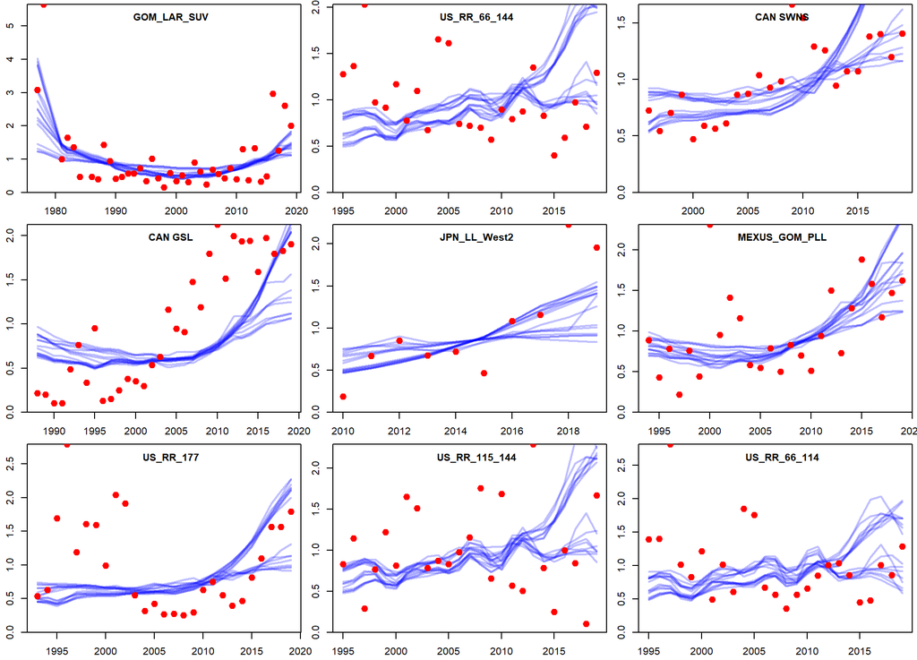

Figure 2. West area indices (red) and OM fits (blue).

|  | Strata | Area | Proposed | n | St.Dev | A.C. | Runs p | Max run 10 | St.Err | Prop. Crs. |
| --- | --- | --- | --- | --- | --- | --- | --- | --- | --- | --- |
| GBYP_AER_SUV_BAR | 7 | MED | Yes | 6 | 0.68 |  |  |  | 0.28 | 0.2 |
| MED_LAR_SUV | 7 | MED | Yes | 14 | 0.83 |  |  |  | 0.22 | 0.38 |
| FR_AER_SUV2 | 7 | MED | Yes | 10 | 0.59 |  |  |  | 0.19 | 0.56 |
| JPN_LL_NEAtl2 | 5 | NATL | Yes | 10 | 0.34 | 0.42 | 0.21 | 4.19 | 0.11 | 0.26 |
| MOR_POR_TRAP | 4 | SATL | Yes | 8 | 0.35 | 0.15 | 0.72 | 3 | 0.12 | 0.59 |

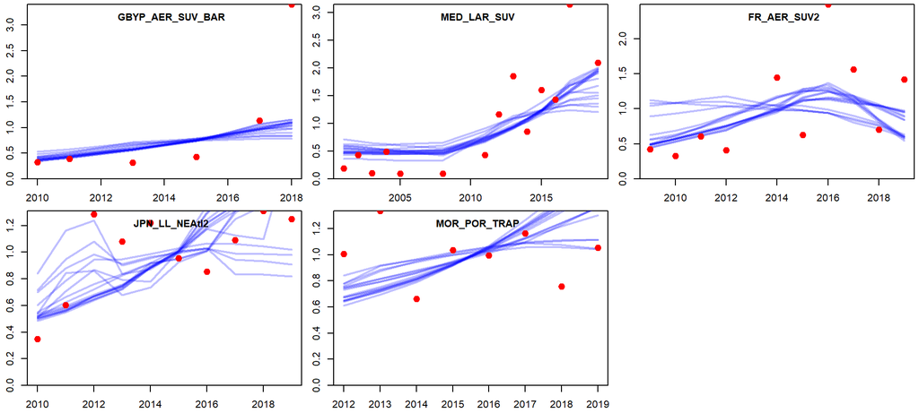

Figure 3. East area indices (red) and OM fits (blue).

# 10 Uncertainty in standard deviation (all OMs)

Table 8a. Uncertainty in standard deviation in log residuals of West area indices (generated by an inverse chi-squared distribution) expressed by the 5th, 25th, 50th, 75th and 95th percentiles.

|  | Strata | Area | Proposed | n | St.Dev | 5th | 25th | 50th | 75th | 95th |
| --- | --- | --- | --- | --- | --- | --- | --- | --- | --- | --- |
| GOM_LAR_SUV | 1 | GOM | Yes | 40 | 0.59 | 0.48 | 0.54 | 0.59 | 0.65 | 0.76 |
| US_RR_66_144 | 2 | WATL | Yes | 25 | 0.54 | 0.37 | 0.44 | 0.54 | 0.66 | 0.8 |
| CAN SWNS | 2 | WATL | Yes | 24 | 0.32 | 0.24 | 0.28 | 0.32 | 0.37 | 0.45 |
| CAN GSL | 3 | GSL | Yes | 32 | 0.86 | 0.69 | 0.79 | 0.87 | 0.96 | 1.12 |
| JPN_LL_West2 | 2 | WATL | Yes | 10 | 0.53 | 0.36 | 0.45 | 0.55 | 0.67 | 0.91 |
| MEXUS_GOM_PLL | 1 | GOM | Yes | 26 | 0.49 | 0.4 | 0.45 | 0.5 | 0.55 | 0.64 |
| US_RR_177 | 2 | WATL | Yes | 27 | 0.76 | 0.61 | 0.7 | 0.77 | 0.86 | 1 |
| US_RR_115_144 | 2 | WATL | Yes | 25 | 0.8 | 0.61 | 0.72 | 0.81 | 0.92 | 1.1 |
| US_RR_66_114 | 2 | WATL | Yes | 25 | 0.62 | 0.46 | 0.55 | 0.63 | 0.72 | 0.87 |

Table 8b. Uncertainty in standard deviation in log residuals of East area indices (generated by an inverse chi-squared distribution) expressed by the 5th, 25th, 50th, 75th and 95th percentiles.

|  | Strata | Area | Proposed | n | St.Dev | 5th | 25th | 50th | 75th | 95th |
| --- | --- | --- | --- | --- | --- | --- | --- | --- | --- | --- |
| GBYP_AER_SUV_BAR | 7 | MED | Yes | 6 | 0.68 | 0.45 | 0.59 | 0.72 | 0.91 | 1.35 |
| MED_LAR_SUV | 7 | MED | Yes | 14 | 0.83 | 0.62 | 0.75 | 0.85 | 0.99 | 1.25 |
| FR_AER_SUV2 | 7 | MED | Yes | 10 | 0.59 | 0.38 | 0.48 | 0.59 | 0.75 | 1.05 |
| JPN_LL_NEAtl2 | 5 | NATL | Yes | 10 | 0.34 | 0.24 | 0.3 | 0.35 | 0.42 | 0.56 |
| MOR_POR_TRAP | 4 | SATL | Yes | 8 | 0.35 | 0.22 | 0.29 | 0.36 | 0.45 | 0.63 |

# 11 Interquantile ranges of SD estimates

Table 9a. The 25th percentile of the sampled St.Dev by index and operating model

| OM | R | P | S | L | MOR POR TRAP | JPN LL NEAtl2 | US RR 66 114 | US RR 115 144 | US RR 177 | MEXUS GOM PLL | JPN LL West2 | CAN GSL | CAN SWNS | US RR 66 144 | FR AER SUV2 | MED LAR SUV | GOM LAR SUV | GBYP AER SUV BAR |
| --- | --- | --- | --- | --- | --- | --- | --- | --- | --- | --- | --- | --- | --- | --- | --- | --- | --- | --- |
| 25 | 1 | A | -- | H | 0.37 | 0.33 | 0.61 | 0.8 | 0.72 | 0.48 | 0.4 | 0.76 | 0.34 | 0.57 | 0.42 | 0.72 | 0.5 | 0.53 |
| 26 | 2 | A | -- | H | 0.25 | 0.25 | 0.49 | 0.65 | 0.67 | 0.44 | 0.59 | 0.88 | 0.27 | 0.38 | 0.66 | 0.78 | 0.55 | 0.69 |
| 28 | 1 | B | -- | H | 0.37 | 0.32 | 0.62 | 0.79 | 0.72 | 0.47 | 0.39 | 0.75 | 0.35 | 0.58 | 0.44 | 0.74 | 0.5 | 0.55 |
| 29 | 2 | B | -- | H | 0.22 | 0.4 | 0.48 | 0.65 | 0.69 | 0.43 | 0.61 | 0.83 | 0.25 | 0.38 | 0.73 | 0.86 | 0.52 | 0.75 |
| 31 | 1 | A | -+ | H | 0.34 | 0.31 | 0.61 | 0.81 | 0.71 | 0.47 | 0.41 | 0.76 | 0.32 | 0.56 | 0.43 | 0.71 | 0.5 | 0.52 |
| 32 | 2 | A | -+ | H | 0.28 | 0.28 | 0.52 | 0.68 | 0.66 | 0.44 | 0.48 | 0.8 | 0.26 | 0.41 | 0.5 | 0.75 | 0.51 | 0.6 |
| 34 | 1 | B | -+ | H | 0.34 | 0.31 | 0.62 | 0.8 | 0.74 | 0.47 | 0.4 | 0.74 | 0.33 | 0.57 | 0.45 | 0.74 | 0.5 | 0.56 |
| 35 | 2 | B | -+ | H | 0.29 | 0.31 | 0.5 | 0.69 | 0.66 | 0.44 | 0.46 | 0.83 | 0.26 | 0.41 | 0.51 | 0.59 | 0.53 | 0.6 |
| 37 | 1 | A | +- | H | 0.4 | 0.33 | 0.7 | 0.87 | 0.76 | 0.46 | 0.39 | 0.78 | 0.35 | 0.66 | 0.44 | 0.71 | 0.55 | 0.56 |
| 38 | 2 | A | +- | H | 0.29 | 0.25 | 0.51 | 0.67 | 0.64 | 0.45 | 0.54 | 0.91 | 0.27 | 0.39 | 0.55 | 0.86 | 0.64 | 0.62 |

[output cut: 6 more lines]

Table 9b. The 75th percentile of the sampled St.Dev by index and operating model

| OM | R | P | S | L | MOR POR TRAP | JPN LL NEAtl2 | US RR 66 114 | US RR 115 144 | US RR 177 | MEXUS GOM PLL | JPN LL West2 | CAN GSL | CAN SWNS | US RR 66 144 | FR AER SUV2 | MED LAR SUV | GOM LAR SUV | GBYP AER SUV BAR |
| --- | --- | --- | --- | --- | --- | --- | --- | --- | --- | --- | --- | --- | --- | --- | --- | --- | --- | --- |
| 25 | 1 | A | -- | H | 0.53 | 0.45 | 0.74 | 0.98 | 0.86 | 0.58 | 0.54 | 0.9 | 0.41 | 0.7 | 0.57 | 0.93 | 0.59 | 0.79 |
| 26 | 2 | A | -- | H | 0.36 | 0.34 | 0.6 | 0.8 | 0.8 | 0.52 | 0.81 | 1.05 | 0.33 | 0.46 | 0.91 | 0.99 | 0.64 | 1.06 |
| 28 | 1 | B | -- | H | 0.51 | 0.44 | 0.76 | 0.98 | 0.87 | 0.56 | 0.54 | 0.89 | 0.43 | 0.7 | 0.6 | 0.97 | 0.59 | 0.84 |
| 29 | 2 | B | -- | H | 0.31 | 0.54 | 0.59 | 0.79 | 0.83 | 0.53 | 0.82 | 1 | 0.3 | 0.47 | 1.01 | 1.14 | 0.61 | 1.15 |
| 31 | 1 | A | -+ | H | 0.49 | 0.42 | 0.75 | 0.98 | 0.86 | 0.58 | 0.56 | 0.89 | 0.39 | 0.68 | 0.58 | 0.91 | 0.58 | 0.78 |
| 32 | 2 | A | -+ | H | 0.39 | 0.38 | 0.63 | 0.83 | 0.8 | 0.53 | 0.68 | 0.95 | 0.32 | 0.5 | 0.7 | 0.96 | 0.58 | 0.9 |
| 34 | 1 | B | -+ | H | 0.48 | 0.42 | 0.75 | 0.97 | 0.89 | 0.56 | 0.55 | 0.87 | 0.4 | 0.69 | 0.61 | 0.95 | 0.58 | 0.83 |
| 35 | 2 | B | -+ | H | 0.41 | 0.42 | 0.61 | 0.85 | 0.81 | 0.53 | 0.62 | 0.97 | 0.31 | 0.51 | 0.71 | 0.78 | 0.62 | 0.9 |
| 37 | 1 | A | +- | H | 0.56 | 0.45 | 0.84 | 1.04 | 0.91 | 0.55 | 0.54 | 0.92 | 0.43 | 0.79 | 0.61 | 0.93 | 0.64 | 0.83 |
| 38 | 2 | A | +- | H | 0.41 | 0.34 | 0.62 | 0.81 | 0.76 | 0.55 | 0.73 | 1.07 | 0.33 | 0.48 | 0.75 | 1.11 | 0.74 | 0.93 |

[output cut: 6 more lines]

Figure 4. The interquartile range of SD estimates by index

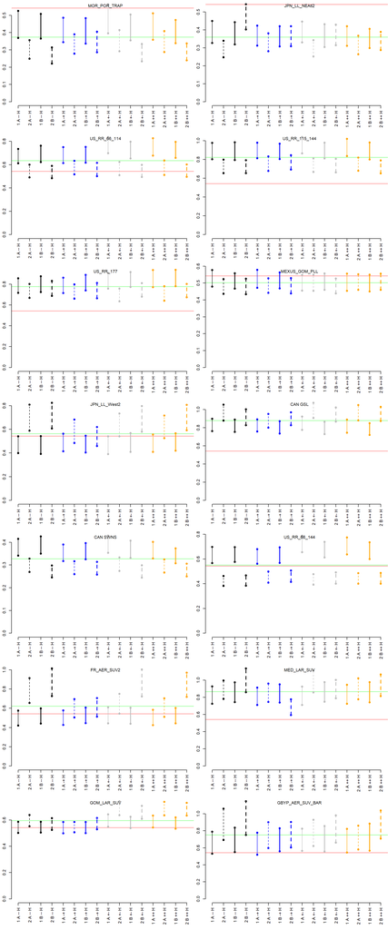